# AXCESSR Data Validity

- Show All Code
- Hide All Code
- View Source

Author

Tilabo Williamson, Caitlin Buenk & Jürgen Becker (Project Lead) - AX Consult Group

Published

2026-04-23

[figure not shown]

Use the navigation panel on the left to move through the three development phases of AXCESSR, and the panel on the right to navigate sections within each phase.

# Background

AXCESSR is a multidimensional candidate risk assessment tool designed to measure personality, values, and emotional risk factors. This section documents the psychometric evaluation of the AXCESSR item pool and the evidence-based item refinement process undertaken prior to scoring. The goal is not to reproduce the full structural model - which constitutes proprietary instrument design - but to demonstrate that the retained item set meets accepted standards for reliability, internal consistency, and discriminant validity.

```r
# Reading in data
validity_data <- read_excel(here("data/AXCESSR_validity_data_isolated - 2026.04.24.xlsx"))
```

# Validation

Validation was conducted in two phases. In Phase 1, structural fit was evaluated using confirmatory factor analysis (CFA). Estimation issues - specifically, non-positive definite covariance matrices - were encountered consistently across domains, precluding CFA as a primary validation tool. This outcome is not uncommon in instruments with a large number of correlated subfactors and continuous item scores, and is well-documented in the psychometric literature.

Phase 2 adopted a composite-based validation approach as the primary evidence framework, supplemented by item response theory (IRT) diagnostics at the item level. This approach evaluates reliability, internal consistency, and item quality directly, without imposing a rigid structural model.

Furthermore, the validation analyses presented here served a dual purpose. Beyond establishing the psychometric integrity of the instrument, they were conducted with an eye toward a Computerised Adaptive Testing (CAT) engine. IRT analyses were run specifically to map item difficulty range and coverage across the full risk spectrum — the information needed to determine whether the current item pool is capable of supporting adaptive item selection. This initial sample provides the first evidence base for those decisions.

Below is a figure outlining the validation process.

```r
# Reading in validation pipeline figure
knitr::include_graphics(here::here("image/axcessr_validation_pipeline.svg"))
```

[figure not shown]

Figure 1

## Validation Summary

Validation was conducted on the full cleaned dataset (after removing low engagement respondents - speeders, boundary cases, etc.).

**EFA:** An initial EFA showed excellent overall fit but revealed many weak or cross‑loading factors. Domain‑level EFAs indicated that some subfactors were not meaningfully separated statistically. This provided evidence for removing items, collapsing certain subfactors into single dimensions and regrouping others into broader factors where the empirical structure diverged from the current specification.

**CFA:** CFA models could not be estimated because the covariance matrices were non‑positive definite. However, the theorized factor structure was still evident in composite‑based correlation plots. Higher‑order factor CFAs were estimable, but they produced poor fit indices. Despite this, these models were retained as indicators of item quality, since the factor loadings continued to demonstrate meaningful cohesion among items.

**Reliability:** Reliability analyses indicated that most subfactors fell below the 0.70 threshold, underscoring limited internal consistency. In addition, r.drop values were examined as item quality indicators. The r.drop statistic reflects the correlation between each item and the total score (excluding that item), with higher values suggesting that the item contributes meaningfully to the overall construct.

**IRT:** IRT analyses were conducted as isolated subfactor models. Results indicated that while some subfactors were strong, others were weak and contained several problematic items. To further evaluate item quality, first‑order (F1) loadings onto the subfactors were examined. These loadings serve as indicators of how well each item aligns with its intended factor, with higher values suggesting stronger cohesion and construct representation.

## Problematic Items

Items were evaluated against a convergent set of three diagnostic criteria, CFA loading, IRT loading and item-total correlation (r.drop.). Flagging required evidence of poor performance on **all three** criteria to proceed to removal consideration.

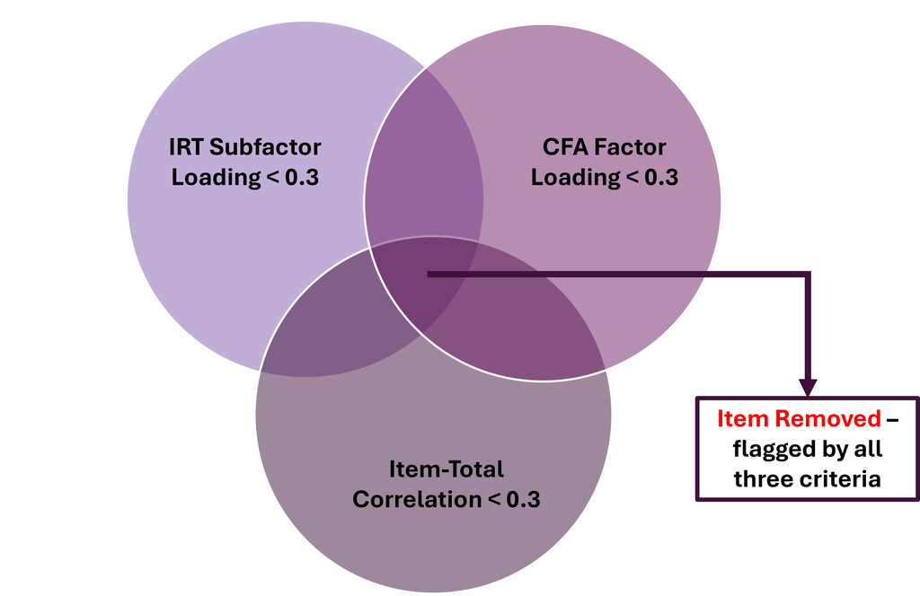

Figure 2

```r
# Reading in problematic item figure
knitr::include_graphics(here::here("image/Item Removal Figure.png"))
```

The below table summarises the criteria and where problematic items were flagged. A total of **41** items were flagged across all three metrics. These items were defined as problematic and removed to create a streamlined 206‑item instrument (V2).

```r
# Problematic item table

flagging_table <- tibble::tribble(
  ~Diagnostic,                                  ~Total, ~Personality, ~Values, ~Emotion_Traits, ~Emotion_States,
  "IRT subfactor loading (< 0.30)",             45,     23,           9,       3,               10,
  "CFA subfactor loading (λ < 0.30)",           75,     41,           15,      5,               14,
  "Item-total correlation (r < 0.30)",          98,     51,           19,      8,               20,
  "Flagged by all three criteria",              41,     22,           9,       2,               8)

flagging_table %>%
  kbl(
    col.names = c("Diagnostic", "Total", "Personality", "Values",
                  "Emotion Traits", "Emotion States"),
    caption   = "Problematic Item Summary",
    align = c("l", "c", "c", "c", "c", "c"),
    escape = FALSE
  ) %>%
  kable_styling(
    bootstrap_options = c("striped", "hover"),
    full_width = TRUE,
    font_size = 14
  ) %>%
  row_spec(0, bold = FALSE) %>%
  row_spec(4, bold = TRUE) %>%
  column_spec(1, width = "40%")
```

Problematic Item Summary

| Diagnostic | Total | Personality | Values | Emotion Traits | Emotion States |
| --- | --- | --- | --- | --- | --- |
| IRT subfactor loading (< 0.30) | 45 | 23 | 9 | 3 | 10 |
| CFA subfactor loading (λ < 0.30) | 75 | 41 | 15 | 5 | 14 |
| Item-total correlation (r < 0.30) | 98 | 51 | 19 | 8 | 20 |
| Flagged by all three criteria | 41 | 22 | 9 | 2 | 8 |

### Score Distribution Comparison

The plots below show the distribution of mean domain-level scores before and after item removal. Improved item quality is expected to yield tighter, better-differentiated distributions with reduced floor and ceiling effects. From the table below, we can see that mean domain scores all shifted downwards slightly after item removal.

```r
# Score Comparison Table

comparison <- validity_data %>%
  select(id,
         # Original scores
         personality_risk, values_risk,
         emotion_traits_risk, emotion_states_risk,
         total_risk_weighted,
             # Revised scores
             personality_risk_check, values_risk_check,
             emotion_traits_risk_check, emotion_states_risk_check,
             total_risk_weighted_check) %>%
  mutate(across(everything(), as.numeric))

# Mean comparison table

comparison_table <- tibble(
  Score = c(
    "Personality Risk", "Values Risk",
    "Emotion Traits Risk", "Emotion States Risk",
    "Total Risk (Weighted)"
  ),
  Original = c(
    mean(comparison$personality_risk,        na.rm = TRUE),
    mean(comparison$values_risk,             na.rm = TRUE),
    mean(comparison$emotion_traits_risk,     na.rm = TRUE),
    mean(comparison$emotion_states_risk,     na.rm = TRUE),
    mean(comparison$total_risk_weighted,     na.rm = TRUE)
  ),
  Revised = c(
    mean(comparison$personality_risk_check,        na.rm = TRUE),
    mean(comparison$values_risk_check,             na.rm = TRUE),
    mean(comparison$emotion_traits_risk_check,     na.rm = TRUE),
    mean(comparison$emotion_states_risk_check,     na.rm = TRUE),
    mean(comparison$total_risk_weighted_check,     na.rm = TRUE)
  )
) %>%
  mutate(
    Difference  = round(Revised - Original, 4),
    Original    = round(Original, 4),
    Revised     = round(Revised, 4)
  )

kbl(comparison_table,
             col.names = c("Score", "Original", "Revised",
                           "Difference"),
             caption   = "Mean Score Comparison: Original vs Revised") %>%
  kable_styling(
    bootstrap_options = c("striped", "hover"),
    full_width = TRUE,
    font_size = 14
  )
```

Mean Score Comparison: Original vs Revised

| Score | Original | Revised | Difference |
| --- | --- | --- | --- |
| Personality Risk | 0.3942 | 0.3838 | -0.0104 |
| Values Risk | 0.2998 | 0.2733 | -0.0265 |
| Emotion Traits Risk | 0.4420 | 0.4398 | -0.0021 |
| Emotion States Risk | 0.4678 | 0.4508 | -0.0170 |
| Total Risk (Weighted) | 0.3840 | 0.3679 | -0.0161 |

### Reliability Comparison

Cronbach’s α was averaged across subfactors within each domain and compared between the original (V1, 247 items) and revised (V2, 206 items) instruments. Three of the four domains showed improvement following item removal, with Personality and Values showing the most meaningful gains. Emotion States improved marginally, and Emotion Traits remained stable - suggesting the removed items were contributing little noise in that domain to begin with. Taken together, these findings indicate that targeted item removal had its intended effect: a modest but consistent improvement in internal consistency without destabilising the existing structure.

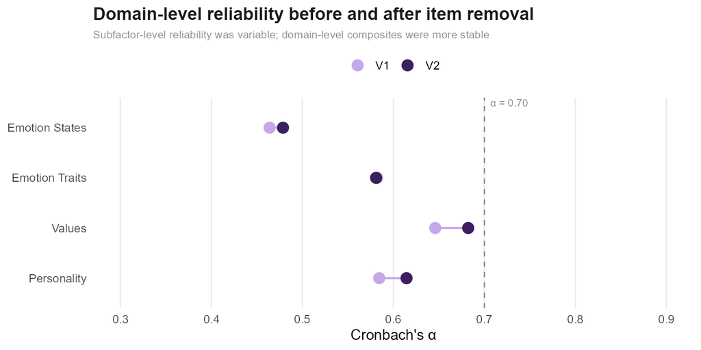

Figure 3

```r
# Domain Reliability Comparison

knitr::include_graphics(here::here("image/reliability_domain_dotplot.png"))
```

### PSI

To assess whether item removal materially altered candidate risk profiles, the Population Stability Index (PSI) was computed between original (V1) and revised (V2) scores at the total and domain level. PSI quantifies the distributional shift between two scoring populations and is widely used in credit risk modelling as a model monitoring metric. Scores below 0.10 indicate a stable distribution; values between 0.10 and 0.25 indicate moderate shift warranting investigation; values above 0.25 indicate significant drift requiring model review.

```r
# PSI scores across key domains

# Total weighted score PSI
psi_total <- psi(
  base   = comparison$total_risk_weighted,
  target = comparison$total_risk_weighted_check,
  bin    = 5,
  alpha  = 0.05
)

# Domain-level PSI
psi_personality <- psi(
  base   = comparison$personality_risk,
  target = comparison$personality_risk_check,
  bin    = 5, alpha = 0.05
)

psi_values <- psi(
  base   = comparison$values_risk,
  target = comparison$values_risk_check,
  bin    = 5, alpha = 0.05
)

psi_emotion_traits <- psi(
  base   = comparison$emotion_traits_risk,
  target = comparison$emotion_traits_risk_check,
  bin    = 5, alpha = 0.05
)

psi_emotion_states <- psi(
  base   = comparison$emotion_states_risk,
  target = comparison$emotion_states_risk_check,
  bin    = 5, alpha = 0.05
)

# Pull just the PSI values cleanly
psi_table <- tibble(
  Score = c("Total Risk (Weighted)", "Personality Risk",
            "Values Risk", "Emotion Traits Risk", "Emotion States Risk"),
  PSI = c(
    psi_total$res$psi,
    psi_personality$res$psi,
    psi_values$res$psi,
    psi_emotion_traits$res$psi,
    psi_emotion_states$res$psi
  ),
  Interpretation = c(
    "Stable - minor shift, no action required",
    "Stable - distribution largely unchanged",
    "Moderate shift - high considering only 9 items were removed",
    "Highly stable - negligible distributional change",
    "Stable - minimal shift across versions"
  )
)

kbl(
  psi_table,
  col.names = c("Score", "PSI", "Interpretation"),
  caption   = "Population Stability Index (PSI) Results"
) %>%
  kable_styling(
    bootstrap_options = c("striped", "hover"),
    full_width = TRUE,
    font_size = 14
  )
```

Population Stability Index (PSI) Results

| Score | PSI | Interpretation |
| --- | --- | --- |
| Total Risk (Weighted) | 0.0997377 | Stable - minor shift, no action required |
| Personality Risk | 0.0283380 | Stable - distribution largely unchanged |
| Values Risk | 0.1884240 | Moderate shift - high considering only 9 items were removed |
| Emotion Traits Risk | 0.0036229 | Highly stable - negligible distributional change |
| Emotion States Risk | 0.0420474 | Stable - minimal shift across versions |

Personality Risk showed a small but acceptable shift (PSI = 0.028), well within the stable range. Values Risk showed the largest shift of the four domains (PSI = 0.188), falling in the moderate range. This is notable given that the Values domain underwent meaningful structural consolidation — the distributional shift reflects genuine refinement of the construct rather than model instability, and remains well below the 0.25 threshold that would require intervention.

Taken together, the PSI results confirm that the revised instrument produces risk classifications that are substantively consistent with the original, while reflecting targeted improvements to construct validity at the domain level.

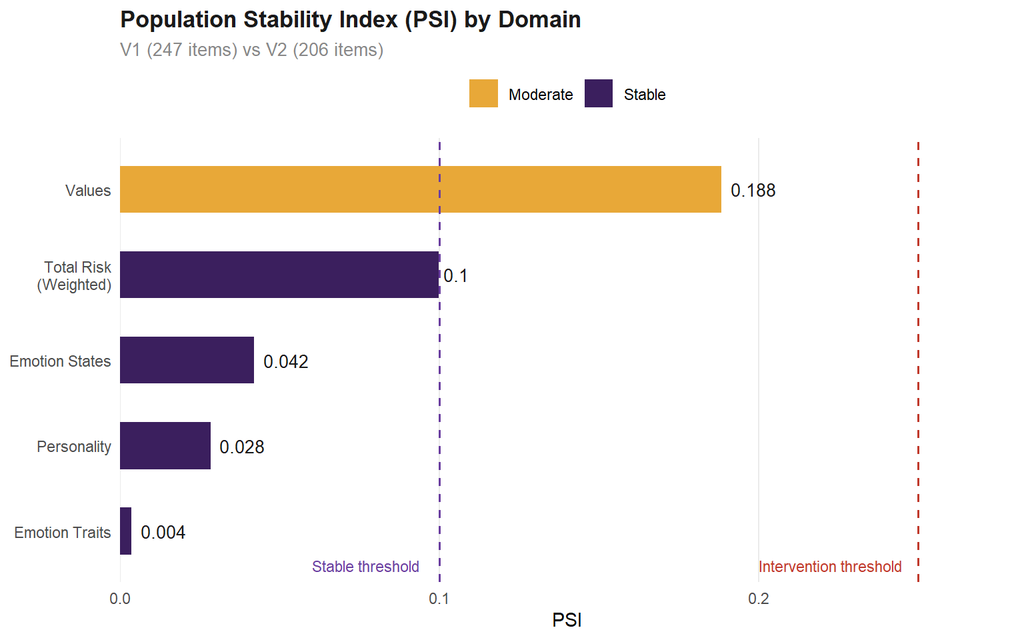

```r
# PSI Bar Chart
psi_df <- tibble(
  Domain = c("Emotion Traits", "Personality", "Emotion States",
             "Total Risk\n(Weighted)", "Values"),
  PSI    = c(0.0036, 0.0283, 0.0420, 0.0997, 0.1884),
  Zone   = case_when(
    PSI < 0.10 ~ "Stable",
    PSI < 0.25 ~ "Moderate",
    TRUE       ~ "Intervention Required"
  )
) %>%
  mutate(Domain = fct_reorder(Domain, PSI))

ggplot(psi_df, aes(x = PSI, y = Domain, fill = Zone)) +
  geom_col(width = 0.55) +
  geom_vline(xintercept = 0.10, linetype = "dashed",
             colour = "#6B3FA0", linewidth = 0.7) +
  geom_vline(xintercept = 0.25, linetype = "dashed",
             colour = "#C0392B", linewidth = 0.7) +
  geom_text(aes(label = round(PSI, 3)),
            hjust = -0.2, size = 3.5, colour = "#1A1A1A") +
  annotate("text", x = 0.06, y = 0.6, label = "Stable threshold",
           hjust = 0, size = 3, colour = "#6B3FA0") +
  annotate("text", x = 0.2, y = 0.6, label = "Intervention threshold",
           hjust = 0, size = 3, colour = "#C0392B") +
  scale_fill_manual(values = c(
    "Stable"    = "#3B1F5E",
    "Moderate"  = "#E8A838"
  )) +
  scale_x_continuous(limits = c(0, 0.28), expand = c(0, 0)) +
  labs(
    title    = "Population Stability Index (PSI) by Domain",
    subtitle = "V1 (247 items) vs V2 (206 items)",
    x        = "PSI",
    y        = NULL,
    fill     = NULL
  ) +
  theme_minimal(base_size = 11) +
  theme(
    plot.title       = element_text(face = "bold", colour = "#1A1A1A"),
    plot.subtitle    = element_text(colour = "#888888", size = 10),
    panel.grid.major.y = element_blank(),
    panel.grid.minor   = element_blank(),
    legend.position  = "top",
    plot.background  = element_rect(fill = "white", colour = NA)
  )
```

```r
ggsave("image/psi_bar.png", width = 12, height = 6, dpi = 180, bg = "white")
```

The bar chart confirms that distributional shift is concentrated in the Values domain. All other domains sit comfortably below the stable threshold, and the total weighted risk score sits precisely at the boundary (PSI = 0.10) - indicating that at the overall scoring level, V1 and V2 produce near-equivalent candidate classifications.

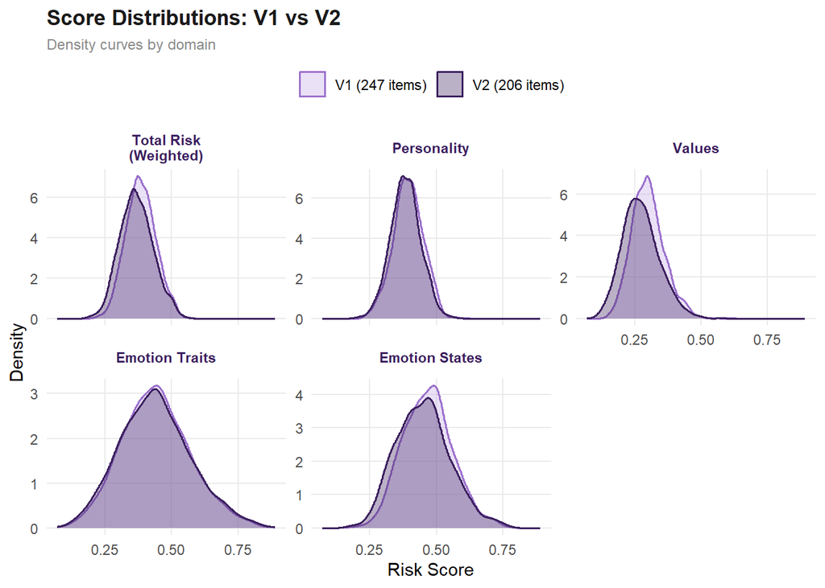

```r
# Density Overlays

score_long <- comparison %>%
  select(
    `Total Risk\n(Weighted)` = total_risk_weighted,
    `Total Risk\n(Weighted) V2` = total_risk_weighted_check,
    Personality = personality_risk,
    `Personality V2` = personality_risk_check,
    Values = values_risk,
    `Values V2` = values_risk_check,
    `Emotion Traits` = emotion_traits_risk,
    `Emotion Traits V2` = emotion_traits_risk_check,
    `Emotion States` = emotion_states_risk,
    `Emotion States V2` = emotion_states_risk_check
  ) %>%
  pivot_longer(everything(), names_to = "Domain", values_to = "Score") %>%
  mutate(
    Version = if_else(str_detect(Domain, "V2"), "V2 (206 items)", "V1 (247 items)"),
    Domain  = str_remove(Domain, " V2"),
    Domain  = factor(
      Domain,
      levels = c(
        "Total Risk\n(Weighted)",
        "Personality",
        "Values",
        "Emotion Traits",
        "Emotion States"
      )
    )
  )

ggplot(score_long, aes(x = Score, fill = Version, colour = Version)) +
  geom_density(alpha = 0.35, linewidth = 0.7) +
  facet_wrap(~ Domain, scales = "free_y", ncol = 3) +
  scale_fill_manual(values = c(
    "V1 (247 items)" = "#C4A8E8",
    "V2 (206 items)" = "#3B1F5E"
  )) +
  scale_colour_manual(values = c(
    "V1 (247 items)" = "#9B70CC",
    "V2 (206 items)" = "#3B1F5E"
  )) +
  labs(
    title    = "Score Distributions: V1 vs V2",
    subtitle = "Density curves by domain",
    x        = "Risk Score",
    y        = "Density",
    fill     = NULL, colour = NULL
  ) +
  theme_minimal(base_size = 11) +
  theme(
    plot.title         = element_text(face = "bold", colour = "#1A1A1A"),
    plot.subtitle      = element_text(colour = "#888888", size = 9),
    strip.text         = element_text(face = "bold", colour = "#3B1F5E"),
    panel.grid.minor   = element_blank(),
    legend.position    = "top",
    plot.background    = element_rect(fill = "white", colour = NA)
  )
```

```r
ggsave("image/psi_density.png", width = 10, height = 6, dpi = 180, bg = "white")
```

## Further Structural Recommendations

Item and factor analysis identified several subfactors with overlapping variance structures, supporting consolidation of theoretically adjacent constructs. The following structural revisions are recommended prior to finalising the scoring model.

```r
# Structural Recommendations

structural_table <- tibble::tribble(
  ~Original,                                      ~Recommended,                        ~Rationale,
  "Stress Tolerance, Flexibility, Optimism",      "Collapse \u2192 Adjustment",    "High inter-subfactor correlations; indistinct factor profiles",
    "Dependence",                                   "Flag for item redevelopment or removal",   "Cross-loaded across factors",
  "Compulsivity, Impulsivity and Boredom",                        "Collapse \u2192 Dysregulation", "Shared item content bar some Impulsivity items",
  "Control, Fearfulness, Anxiety",                "Collapse \u2192 Affectivity",   "Empirically inseparable; theoretically coherent at factor level"
)

structural_table %>%
  kbl(
    col.names = c("Original Subfactors", "Recommended Structure", "Rationale"),
    align = c("l", "l", "l"),
    escape = FALSE
  ) %>%
  kable_styling(
    bootstrap_options = c("striped", "hover"),
    full_width = TRUE,
    font_size = 14
  ) %>%
  row_spec(0, bold = FALSE) %>%
  column_spec(1, width = "30%") %>%
  column_spec(2, width = "25%") %>%
  column_spec(3, width = "45%")
```

| Original Subfactors | Recommended Structure | Rationale |
| --- | --- | --- |
| Stress Tolerance, Flexibility, Optimism | Collapse → Adjustment | High inter-subfactor correlations; indistinct factor profiles |
| Dependence | Flag for item redevelopment or removal | Cross-loaded across factors |
| Compulsivity, Impulsivity and Boredom | Collapse → Dysregulation | Shared item content bar some Impulsivity items |
| Control, Fearfulness, Anxiety | Collapse → Affectivity | Empirically inseparable; theoretically coherent at factor level |

# Conclusion

What the data cannot yet confirm is whether these findings generalise. A second independent dataset is in preparation, and final decisions on item removal and structural consolidation are contingent on cross-sample replication. The current findings establish a clear evidential baseline — the next dataset will determine whether that baseline holds.